# Exploratory Factor Analysis

```r
library(tidyverse)
library(broom)
library(psych)
library(EFAtools)
library(lavaan)
library(semTools)
library(ClustOfVar)
```

data:

```r
df = read.csv("~/GitHub/lendulet_language_SL/SEM/dataframes/filtered_SEM_df.csv")
```

# 1. Statistical learning variables

Kaiser-Meyer-Olkin test

```r
df %>%
  select(
    SEGM_AL_medRT_train,
    SEGM_AL_medRT_TRN3_RND4,
    SEGM_AL_medRT_RND4_REC5,
    #SEGM_AL_ACC_train,
    SEGM_AL_ACC_TRN3_RND4,
    #SEGM_AL_ACC_RND4_REC5,
    #AGL_ACC_train,
    SEGM_AL_2AFC_bigram,
    SEGM_AL_2AFC_trigram,
    SEGM_AL_SEGM_prod_data,
    AGL_2AFC_phr,
    AGL_2AFC_sent,
    AGL_prod
  ) %>%
KMO()
```

```
ℹ 'x' was not a correlation matrix. Correlations are found from entered raw data.
```

```
── Kaiser-Meyer-Olkin criterion (KMO) ───────────────────────────────────────────────────────────────────────────────────────────

! The overall KMO value for your data is mediocre.
  These data are probably suitable for factor analysis.

  Overall: 0.612

  For each variable:
    SEGM_AL_medRT_train SEGM_AL_medRT_TRN3_RND4 SEGM_AL_medRT_RND4_REC5   SEGM_AL_ACC_TRN3_RND4     SEGM_AL_2AFC_bigram
                  0.581                   0.545                   0.603                   0.487                   0.596
   SEGM_AL_2AFC_trigram  SEGM_AL_SEGM_prod_data            AGL_2AFC_phr           AGL_2AFC_sent                AGL_prod
                  0.705                   0.813                   0.604                   0.680                   0.637
```

Consequently, we omitted those variables which showed unacceptable for EFA (<0.5): - SEGM_AL_ACC_train - SEGM_AL_ACC_TRN3_RND4 - SEGM_AL_ACC_RND4_REC5 - AGL_ACC_train

```r
df %>%
  select(
    SEGM_AL_medRT_train,
    SEGM_AL_medRT_TRN3_RND4,
    SEGM_AL_medRT_RND4_REC5,
    SEGM_AL_2AFC_bigram,
    SEGM_AL_2AFC_trigram,
    SEGM_AL_SEGM_prod_data,
    AGL_2AFC_phr,
    AGL_2AFC_sent,
    AGL_prod
  ) %>%
KMO()
```

```
ℹ 'x' was not a correlation matrix. Correlations are found from entered raw data.
```

```
── Kaiser-Meyer-Olkin criterion (KMO) ───────────────────────────────────────────────────────────────────────────────────────────

! The overall KMO value for your data is mediocre.
  These data are probably suitable for factor analysis.

  Overall: 0.615

  For each variable:
    SEGM_AL_medRT_train SEGM_AL_medRT_TRN3_RND4 SEGM_AL_medRT_RND4_REC5     SEGM_AL_2AFC_bigram    SEGM_AL_2AFC_trigram
                  0.581                   0.545                   0.603                   0.595                   0.705
 SEGM_AL_SEGM_prod_data            AGL_2AFC_phr           AGL_2AFC_sent                AGL_prod
                  0.831                   0.604                   0.703                   0.642
```

# 1.1. RT variables

Bartlett’s test

```r
df %>%
  select(
    SEGM_AL_medRT_train,
    SEGM_AL_medRT_TRN3_RND4,
    SEGM_AL_medRT_RND4_REC5,
  ) %>%
BARTLETT()
```

```
ℹ 'x' was not a correlation matrix. Correlations are found from entered raw data.
```

```
✔ The Bartlett's test of sphericity was significant at an alpha level of .05.
  These data are probably suitable for factor analysis.

  𝜒²(3) = 799.62, p < .001
```

```
Parallel analysis suggests that the number of factors =  2  and the number of components =  NA
```

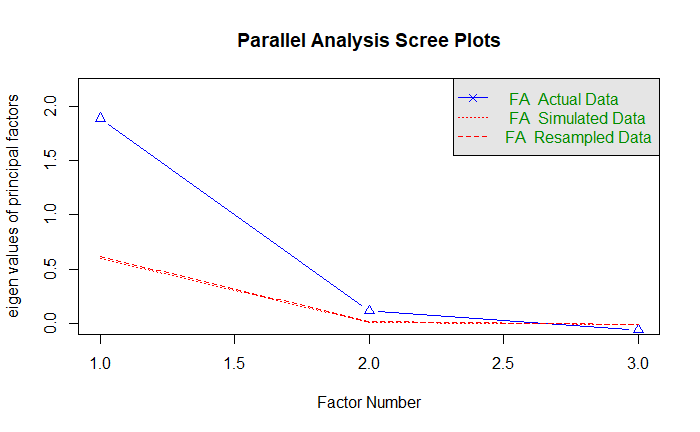

```r
df %>%
  select(
    SEGM_AL_medRT_train,
    SEGM_AL_medRT_TRN3_RND4,
    SEGM_AL_medRT_RND4_REC5,
  ) %>%
    fa.parallel(fm = "ml", fa = "fa")
```

```r
SL_EFA = df %>%
  select(
    SEGM_AL_medRT_train,
    SEGM_AL_medRT_TRN3_RND4,
    SEGM_AL_medRT_RND4_REC5,
  ) %>%
  # maximum likelihood
  fa(
    nfactors = 1,
    fm = "ml",
    rotate = "Promax",
    use = "pairwise",
    cor = "cor",
    scores = "regression",
    missing = TRUE,
    impute = "mean"
    )
```

```r
summary(SL_EFA)
```

```
Factor analysis with Call: fa(r = ., nfactors = 1, rotate = "Promax", scores = "regression",
    missing = TRUE, impute = "mean", fm = "ml", use = "pairwise",
    cor = "cor")

Test of the hypothesis that 1 factor is sufficient.
The degrees of freedom for the model is 0  and the objective function was  0.05
The number of observations was  608  with Chi Square =  28.44  with prob <  NA

The root mean square of the residuals (RMSA) is  0.06
The df corrected root mean square of the residuals is  NA

Tucker Lewis Index of factoring reliability =  -Inf
```

```r
SL_EFA$loadings
```

```
Loadings:
                        ML1
SEGM_AL_medRT_train     0.690
SEGM_AL_medRT_TRN3_RND4 0.998
SEGM_AL_medRT_RND4_REC5 0.685

                 ML1
SS loadings    1.941
Proportion Var 0.647
```

```r
tidy(SL_EFA$uniquenesses)
```

| names | x |
| --- | --- |
| SEGM_AL_medRT_train | 0.523464054 |
| SEGM_AL_medRT_TRN3_RND4 | 0.004990382 |
| SEGM_AL_medRT_RND4_REC5 | 0.530461398 |

# 1.2. Offline variables

Bartlett’s test

```r
df %>%
  select(
    SEGM_AL_2AFC_bigram,
    SEGM_AL_2AFC_trigram,
    SEGM_AL_SEGM_prod_data,
    AGL_2AFC_phr,
    AGL_2AFC_sent,
    AGL_prod
  ) %>%
BARTLETT()
```

```
ℹ 'x' was not a correlation matrix. Correlations are found from entered raw data.
```

```
✔ The Bartlett's test of sphericity was significant at an alpha level of .05.
  These data are probably suitable for factor analysis.

  𝜒²(15) = 356.5, p < .001
```

```
Parallel analysis suggests that the number of factors =  2  and the number of components =  NA
```

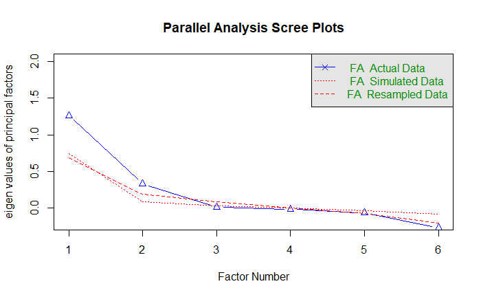

```r
df %>%
  select(
    SEGM_AL_2AFC_bigram,
    SEGM_AL_2AFC_trigram,
    SEGM_AL_SEGM_prod_data,
    AGL_2AFC_phr,
    AGL_2AFC_sent,
    AGL_prod
  ) %>%
    fa.parallel(fm = "ml", fa = "fa")
```

Parallel analysis indicates 2 factors.

```r
SL_OFF = df %>%
  select(
    SEGM_AL_2AFC_bigram,
    SEGM_AL_2AFC_trigram,
    SEGM_AL_SEGM_prod_data,
    AGL_2AFC_phr,
    AGL_2AFC_sent,
    AGL_prod
  ) %>%
  # maximum likelihood
  fa(
    nfactors = 2,
    fm = "ml",
    rotate = "Promax",
    use = "pairwise",
    cor = "cor",
    scores = "regression",
    missing = TRUE,
    impute = "mean"
    )
```

```r
summary(SL_OFF)
```

```
Factor analysis with Call: fa(r = ., nfactors = 2, rotate = "Promax", scores = "regression",
    missing = TRUE, impute = "mean", fm = "ml", use = "pairwise",
    cor = "cor")

Test of the hypothesis that 2 factors are sufficient.
The degrees of freedom for the model is 4  and the objective function was  0.02
The number of observations was  608  with Chi Square =  9.05  with prob <  0.06

The root mean square of the residuals (RMSA) is  0.02
The df corrected root mean square of the residuals is  0.05

Tucker Lewis Index of factoring reliability =  0.944
RMSEA index =  0.046  and the 10 % confidence intervals are  0 0.086
BIC =  -16.59
 With factor correlations of
     ML1  ML2
ML1 1.00 0.39
ML2 0.39 1.00
```

```r
SL_OFF$loadings
```

```
Loadings:
                       ML1    ML2
SEGM_AL_2AFC_bigram     0.316
SEGM_AL_2AFC_trigram    1.020
SEGM_AL_SEGM_prod_data  0.150  0.336
AGL_2AFC_phr                   0.442
AGL_2AFC_sent                  0.700
AGL_prod                       0.562

                 ML1   ML2
SS loadings    1.173 1.122
Proportion Var 0.196 0.187
Cumulative Var 0.196 0.382
```

```r
tidy(SL_OFF$uniquenesses)
```

| names | x |
| --- | --- |
| SEGM_AL_2AFC_bigram | 0.880997809 |
| SEGM_AL_2AFC_trigram | 0.004999984 |
| SEGM_AL_SEGM_prod_data | 0.824838497 |
| AGL_2AFC_phr | 0.825572052 |
| AGL_2AFC_sent | 0.542866463 |
| AGL_prod | 0.678634295 |

Since the 2-factor model were showed a complex structure, we proceeded with cluster analysis to reveal single variable factors.

```r
tree_01 = df %>%
  select(
    SEGM_AL_medRT_train,
    SEGM_AL_medRT_TRN3_RND4,
    SEGM_AL_medRT_RND4_REC5,
    SEGM_AL_2AFC_bigram,
    SEGM_AL_2AFC_trigram,
    SEGM_AL_SEGM_prod_data,
    AGL_2AFC_phr,
    AGL_2AFC_sent,
    AGL_prod
  ) %>%
hclustvar()
```

[figure not shown]

```r
plot(tree_01)
```

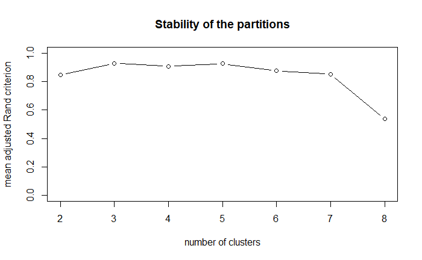

```r
stab = stability(tree_01, B=100)
```

Since the Rand criterion shows that there is two local maximum (at 3 and 5) regarding the number of clusters, we chose the bigger number for more detailed analysis.

```r
km = df %>%
  select(
    SEGM_AL_medRT_train,
    SEGM_AL_medRT_TRN3_RND4,
    SEGM_AL_medRT_RND4_REC5,
    SEGM_AL_2AFC_bigram,
    SEGM_AL_2AFC_trigram,
    SEGM_AL_SEGM_prod_data,
    AGL_2AFC_phr,
    AGL_2AFC_sent,
    AGL_prod
  ) %>%
kmeansvar(init = 5, nstart = 1000)
```

```r
summary(km)
```

```
Call:
kmeansvar(X.quanti = ., init = 5, nstart = 1000)

number of iterations:  1

Data:
   number of observations:  608
   number of variables:  9
   number of clusters:  5

Cluster  1 :
                        squared loading correlation
SEGM_AL_medRT_TRN3_RND4            0.89       -0.94
SEGM_AL_medRT_train                0.64       -0.80
SEGM_AL_medRT_RND4_REC5            0.64       -0.80


Cluster  2 :
                     squared loading correlation
SEGM_AL_2AFC_bigram             0.67       -0.82
SEGM_AL_2AFC_trigram            0.67       -0.82


Cluster  3 :
squared loading     correlation
              1               1


Cluster  4 :
squared loading     correlation
              1               1


Cluster  5 :
              squared loading correlation
AGL_2AFC_sent            0.69       -0.83
AGL_prod                 0.69       -0.83


Gain in cohesion (in %):  67.34
```

In conclusion, we used these 5 clusters of statistical learning variables to identify latent variables which serve as predictors in the SEM models. We tested the structure with cfa.

```r
model_SL =
"
  SL_RT =~ SEGM_AL_medRT_train + SEGM_AL_medRT_TRN3_RND4 + SEGM_AL_medRT_RND4_REC5
  SL_tribi =~ SEGM_AL_2AFC_bigram + SEGM_AL_2AFC_trigram
  SL_SEGM_prod =~ SEGM_AL_SEGM_prod_data
  SL_AGL =~ AGL_2AFC_sent + AGL_prod
  SL_phr =~ AGL_2AFC_phr
"
```

```r
model_SL_fit = cfa(model_SL, df, missing = "ML", estimator = "MLR")
summary(model_SL_fit, standardized = TRUE, fit.measures = TRUE)
```

```
lavaan 0.6.16 ended normally after 51 iterations

  Estimator                                         ML
  Optimization method                           NLMINB
  Number of model parameters                        35

                                                  Used       Total
  Number of observations                           386         608
  Number of missing patterns                        11

Model Test User Model:
                                              Standard      Scaled
  Test Statistic                                29.141      30.182
  Degrees of freedom                                19          19
  P-value (Chi-square)                           0.064       0.050
  Scaling correction factor                                  0.966
    Yuan-Bentler correction (Mplus variant)

Model Test Baseline Model:

  Test statistic                               559.241     481.464
  Degrees of freedom                                36          36
  P-value                                        0.000       0.000
  Scaling correction factor                                  1.162

User Model versus Baseline Model:

  Comparative Fit Index (CFI)                    0.981       0.975
  Tucker-Lewis Index (TLI)                       0.963       0.952

  Robust Comparative Fit Index (CFI)                         0.983
  Robust Tucker-Lewis Index (TLI)                            0.967

Loglikelihood and Information Criteria:

  Loglikelihood user model (H0)              -3119.162   -3119.162
  Scaling correction factor                                  1.218
      for the MLR correction
  Loglikelihood unrestricted model (H1)      -3104.591   -3104.591
  Scaling correction factor                                  1.129
```

[output cut: 82 more lines]

```
                   Estimate  Std.Err  z-value  P(>|z|)   Std.lv  Std.all
   .SEGM_AL_mdRT_t    0.406    0.072    5.595    0.000    0.406    0.598
   .SEGM_AL_RT_TRN   -0.165    0.101   -1.629    0.103   -0.165   -0.194
   .SEGM_AL_RT_RND    0.532    0.100    5.344    0.000    0.532    0.608
   .SEGM_AL_2AFC_b    0.857    0.091    9.387    0.000    0.857    0.850
   .SEGM_AL_2AFC_t    0.264    0.290    0.911    0.362    0.264    0.251
   .SEGM_AL_SEGM__    0.000                               0.000    0.000
   .AGL_2AFC_sent     0.585    0.105    5.568    0.000    0.585    0.600
   .AGL_prod          0.603    0.106    5.713    0.000    0.603    0.623
   .AGL_2AFC_phr      0.000                               0.000    0.000
    SL_RT             0.273    0.058    4.740    0.000    1.000    1.000
    SL_tribi          0.152    0.074    2.059    0.040    1.000    1.000
    SL_SEGM_prod      0.920    0.064   14.389    0.000    1.000    1.000
    SL_AGL            0.390    0.112    3.492    0.000    1.000    1.000
    SL_phr            0.966    0.080   12.034    0.000    1.000    1.000
```

In one case (SEGM_bigram), the unexplained variance was high (>0.65), however we kept it to assign convergent reliability to the trigram variable. We further discarded the SEGM_AL_midRT_train variable to solve the Heywood case of this factor.

The final grouping of the variables is:

1.SL_RT - SEGM_AL_medRT_TRN3_RND4 - SEGM_AL_medRT_RND4_REC5

2. SL_tribi
- SEGM_AL_2AFC_trigram
- SEGM_AL_2AFC_bigram (for reliability purpose)
3. SL_SEGM_prod
- SEGM_AL_SEGM_prod_data
4. SL_AGL_sent
- AGL_2AFC_sent
- AGL_prod
5. SL_AGL_phr
- AGL_2AFC_phr

# 2. General cognitive variables

Kaiser-Meyer-Olkin test

```r
df %>%
  select(
    PROC_SPEED_vis_RT_med,
    PROC_SPEED_ac_RT_med,
    PROC_SPEED_vis_dec_RT_med,
    digit_span_forward_span,
    digit_span_backward_span,
    n_back_nback_1_dprime,
    n_back_nback_2_dprime,
    n_back_nback_3_dprime,
    stroop_RT_score,
    stroop_ACC_score,
    simon_RT_score,
    simon_ACC_score
  ) %>%
KMO()
```

```r
df %>%
  select(
    PROC_SPEED_vis_RT_med,
    PROC_SPEED_ac_RT_med,
    PROC_SPEED_vis_dec_RT_med,
    digit_span_forward_span,
    digit_span_backward_span,
    n_back_nback_1_dprime,
    n_back_nback_2_dprime,
    n_back_nback_3_dprime,
    stroop_RT_score,
    simon_RT_score,
  ) %>%
KMO()
```

```r
df %>%
  select(
    PROC_SPEED_vis_RT_med,
    PROC_SPEED_ac_RT_med,
    PROC_SPEED_vis_dec_RT_med,
    digit_span_forward_span,
    digit_span_backward_span,
    n_back_nback_1_dprime,
    n_back_nback_2_dprime,
    n_back_nback_3_dprime,
    stroop_RT_score,
    simon_RT_score,
  ) %>%
BARTLETT()
```

```r
df %>%
  select(
    PROC_SPEED_vis_RT_med,
    PROC_SPEED_ac_RT_med,
    PROC_SPEED_vis_dec_RT_med,
    digit_span_forward_span,
    digit_span_backward_span,
    n_back_nback_1_dprime,
    n_back_nback_2_dprime,
    n_back_nback_3_dprime,
    stroop_RT_score,
    simon_RT_score,
  ) %>%
    fa.parallel(fm = "ml", fa = "fa")
```

```r
COG_EFA = df %>%
  select(
    PROC_SPEED_vis_RT_med,
    PROC_SPEED_ac_RT_med,
    PROC_SPEED_vis_dec_RT_med,
    digit_span_forward_span,
    digit_span_backward_span,
    n_back_nback_1_dprime,
    n_back_nback_2_dprime,
    n_back_nback_3_dprime,
    stroop_RT_score,
    simon_RT_score,
  ) %>%
  # maximum likelihood
  fa(
    nfactors = 4,
    fm = "ml",
    rotate = "Promax",
    use = "pairwise",
    cor = "cor",
    scores = "regression",
    missing = TRUE,
    impute = "mean"
    )
```

```r
summary(COG_EFA)
```

```r
COG_EFA$loadings
tidy(COG_EFA$uniquenesses)
```

For further analysis, we performed variable clustering on the general cognitive variables as well.

```r
tree_01 = df %>%
  select(
    PROC_SPEED_vis_RT_med,
    PROC_SPEED_ac_RT_med,
    PROC_SPEED_vis_dec_RT_med,
    digit_span_forward_span,
    digit_span_backward_span,
    n_back_nback_1_dprime,
    n_back_nback_2_dprime,
    n_back_nback_3_dprime,
    stroop_RT_score,
    simon_RT_score,
  ) %>%
hclustvar()
```

```r
plot(tree_01)
```

```r
stab = stability(tree_01, B=100)
```

```r
km = df %>%
  select(
    PROC_SPEED_vis_RT_med,
    PROC_SPEED_ac_RT_med,
    PROC_SPEED_vis_dec_RT_med,
    digit_span_forward_span,
    digit_span_backward_span,
    n_back_nback_1_dprime,
    n_back_nback_2_dprime,
    n_back_nback_3_dprime,
    stroop_RT_score,
    simon_RT_score,
  ) %>%
kmeansvar(init = 4, nstart = 1000)
```

```r
summary(km)
```

In conclusion, we have 4 clusters of cognitive variables:

1.Processing Speed: PROC_SPEED_vis_RT_med, PROC_SPEED_ac_RT_med, PROC_SPEED_vis_dec_RT_med

2.Digit Span: digit_span_forward_span, digit_span_backward_span

3.NBACK test: n_back_nback_1_dprime, n_back_nback_2_dprime, n_back_nback_3_dprime

4.Reaction Time: stroop_RT_score, simon_RT_score

Next we test whether these factors have good fit using cfa.

```r
model_COG =
"
  COG_PS =~ PROC_SPEED_vis_RT_med + PROC_SPEED_vis_dec_RT_med + PROC_SPEED_ac_RT_med
  COG_DS =~ digit_span_forward_span + digit_span_backward_span
  COG_nback =~ n_back_nback_1_dprime + n_back_nback_2_dprime + n_back_nback_3_dprime
  COG_RT =~ stroop_RT_score + simon_RT_score
"
```

```r
model_COG_fit = cfa(model_COG, df, missing = "ML", estimator = "MLR")
summary(model_COG_fit, standardized = TRUE, fit.measures = TRUE)
```

To split the COG_PS into two factor, we performed two cfa analyses with nested models (model_PS_01 and model_PS_02).

```r
model_PS_01 =
"
  PS_01 =~ PROC_SPEED_vis_RT_med + PROC_SPEED_vis_dec_RT_med
  PS_02 =~ PROC_SPEED_ac_RT_med
  COG_DS =~ digit_span_forward_span + digit_span_backward_span
  COG_nback =~ n_back_nback_2_dprime + n_back_nback_3_dprime
  COG_stroop =~ stroop_RT_score
  COG_simon =~ simon_RT_score
"
```

```r
model_PS_01_fit = cfa(model_PS_01, df, missing = "ML", estimator = "MLR")
summary(model_PS_01_fit, standardized = TRUE, fit.measures = TRUE)
```

```r
model_PS_02 =
"
  PS_01 =~ PROC_SPEED_vis_RT_med + PROC_SPEED_ac_RT_med
  PS_02 =~ PROC_SPEED_vis_dec_RT_med
  COG_DS =~ digit_span_forward_span + digit_span_backward_span
  COG_nback =~ n_back_nback_2_dprime + n_back_nback_3_dprime
  COG_stroop =~ stroop_RT_score
  COG_simon =~ simon_RT_score
"
```

```r
model_PS_02_fit = cfa(model_PS_02, df, missing = "ML", estimator = "MLR")
summary(model_PS_02_fit, standardized = TRUE, fit.measures = TRUE)
```

1.Processing Speed: PROC_SPEED_vis_RT_med, PROC_SPEED_ac_RT_med

2.Processing Speed Visual Decision:  
PROC_SPEED_vis_dec_RT_med

3.Digit Span: digit_span_forward_span, digit_span_backward_span

4.NBACK test: n_back_nback_2_dprime, n_back_nback_3_dprime

5.Stroop task: stroop_RT_score

6.Simon task simon_RT_score

# 3. Language related measures

Kaiser-Meyer-Olkin test

```r
df %>%
  select(
    MENYET_mean_ACC_all,
    OMR_read_syls,
    predictive_RT_score,
    predictive_ACC_score,
    selfpaced_target_RT_diff_GP,
    selfpaced_target_RT_diff_sertes,
    trog_pragm_ACC_mean
  ) %>%
KMO()
```

```
ℹ 'x' was not a correlation matrix. Correlations are found from entered raw data.
```

```
── Kaiser-Meyer-Olkin criterion (KMO) ───────────────────────────────────────────────────────────────────────────────────────────

✖ The overall KMO value for your data is miserable.
  These data are hardly suitable for factor analysis.

  Overall: 0.594

  For each variable:
            MENYET_mean_ACC_all                   OMR_read_syls             predictive_RT_score            predictive_ACC_score
                          0.565                           0.673                           0.518                           0.465
    selfpaced_target_RT_diff_GP selfpaced_target_RT_diff_sertes             trog_pragm_ACC_mean
                          0.617                           0.623                           0.620
```

We omitted those variables which showed unacceptable KMO values (<0.5) - predictive_ACC_score

```r
df %>%
  select(
    MENYET_mean_ACC_all,
    OMR_read_syls,
    predictive_RT_score,
    selfpaced_target_RT_diff_GP,
    selfpaced_target_RT_diff_sertes,
    trog_pragm_ACC_mean
  ) %>%
KMO()
```

```
ℹ 'x' was not a correlation matrix. Correlations are found from entered raw data.
```

```
── Kaiser-Meyer-Olkin criterion (KMO) ───────────────────────────────────────────────────────────────────────────────────────────

! The overall KMO value for your data is mediocre.
  These data are probably suitable for factor analysis.

  Overall: 0.624

  For each variable:
            MENYET_mean_ACC_all                   OMR_read_syls             predictive_RT_score     selfpaced_target_RT_diff_GP
                          0.613                           0.670                           0.594                           0.601
selfpaced_target_RT_diff_sertes             trog_pragm_ACC_mean
                          0.628                           0.631
```

All variables are now in the acceptable range (>0.6), and the predictive_RT_score is also near.

```r
df %>%
  select(
    MENYET_mean_ACC_all,
    OMR_read_syls,
    predictive_RT_score,
    selfpaced_target_RT_diff_GP,
    selfpaced_target_RT_diff_sertes,
    trog_pragm_ACC_mean
  ) %>%
    fa.parallel(fm = "ml", fa = "fa")
```

```r
LANG_EFA = df %>%
  select(
    MENYET_mean_ACC_all,
    OMR_read_syls,
    predictive_RT_score,
    selfpaced_target_RT_diff_GP,
    selfpaced_target_RT_diff_sertes,
    trog_pragm_ACC_mean
  ) %>%
  # maximum likelihood
  fa(
    nfactors = 2,
    fm = "ml",
    rotate = "Promax",
    use = "pairwise",
    cor = "cor",
    scores = "regression",
    missing = TRUE,
    impute = "mean"
    )
```

```r
summary(LANG_EFA)
```

```r
LANG_EFA$loadings
tidy(LANG_EFA$uniquenesses)
```

For further analysis, we performed variable clustering on the language variables as well.

```r
tree_01 = df %>%
  select(
    MENYET_mean_ACC_all,
    OMR_read_syls,
    predictive_RT_score,
    selfpaced_target_RT_diff_GP,
    selfpaced_target_RT_diff_sertes,
    trog_pragm_ACC_mean
  ) %>%
hclustvar()
```

```r
plot(tree_01)
```

```r
stab = stability(tree_01, B=100)
```

```r
km = df %>%
  select(
    MENYET_mean_ACC_all,
    OMR_read_syls,
    predictive_RT_score,
    selfpaced_target_RT_diff_GP,
    selfpaced_target_RT_diff_sertes,
    trog_pragm_ACC_mean

  ) %>%
kmeansvar(init = 5, nstart = 1000)
```

```r
summary(km)
```

```
Call:
kmeansvar(X.quanti = ., init = 5, nstart = 1000)

number of iterations:  1

Data:
   number of observations:  608
   number of variables:  6
   number of clusters:  5

Cluster  1 :
squared loading     correlation
              1               1


Cluster  2 :
squared loading     correlation
              1               1


Cluster  3 :
squared loading     correlation
              1               1


Cluster  4 :
                                squared loading correlation
selfpaced_target_RT_diff_GP                0.68        0.82
selfpaced_target_RT_diff_sertes            0.68        0.82


Cluster  5 :
squared loading     correlation
              1               1


Gain in cohesion (in %):  85.03
```

Next we test whether these factors have good fit using cfa.

```r
model_LANG =
"
  LANG_MENYET =~ MENYET_mean_ACC_all
  LANG_OMR =~ OMR_read_syls
  LANG_pred =~ predictive_RT_score
  LANG_space =~ selfpaced_target_RT_diff_GP + selfpaced_target_RT_diff_sertes
  LANG_TROG =~ trog_pragm_ACC_mean
"
```

```r
model_LANG_fit = cfa(model_LANG, df, missing = "ML", estimator = "MLR")
summary(model_LANG_fit, standardized = TRUE, fit.measures = TRUE)
```

```
lavaan 0.6.16 ended normally after 25 iterations

  Estimator                                         ML
  Optimization method                           NLMINB
  Number of model parameters                        24

                                                  Used       Total
  Number of observations                           530         608
  Number of missing patterns                        21

Model Test User Model:
                                              Standard      Scaled
  Test Statistic                                 4.842       5.669
  Degrees of freedom                                 3           3
  P-value (Chi-square)                           0.184       0.129
  Scaling correction factor                                  0.854
    Yuan-Bentler correction (Mplus variant)

Model Test Baseline Model:

  Test statistic                               182.193     152.145
  Degrees of freedom                                15          15
  P-value                                        0.000       0.000
  Scaling correction factor                                  1.197

User Model versus Baseline Model:

  Comparative Fit Index (CFI)                    0.989       0.981
  Tucker-Lewis Index (TLI)                       0.945       0.903

  Robust Comparative Fit Index (CFI)                         0.989
  Robust Tucker-Lewis Index (TLI)                            0.944

Loglikelihood and Information Criteria:

  Loglikelihood user model (H0)              -3578.118   -3578.118
  Scaling correction factor                                  1.470
      for the MLR correction
  Loglikelihood unrestricted model (H1)      -3575.697   -3575.697
  Scaling correction factor                                  1.401
```

[output cut: 73 more lines]

```
    LANG_TROG         0.000                               0.000    0.000

Variances:
                   Estimate  Std.Err  z-value  P(>|z|)   Std.lv  Std.all
   .MENYET_mn_ACC_    0.000                               0.000    0.000
   .OMR_read_syls     0.000                               0.000    0.000
   .predctv_RT_scr    0.000                               0.000    0.000
   .slfpcd__RT__GP    0.678    0.121    5.621    0.000    0.678    0.660
   .slfpcd_tr_RT__    0.454    0.109    4.175    0.000    0.454    0.614
   .trg_prgm_ACC_m    0.000                               0.000    0.000
    LANG_MENYET       0.987    0.081   12.189    0.000    1.000    1.000
    LANG_OMR          0.984    0.087   11.370    0.000    1.000    1.000
    LANG_pred         1.020    0.042   24.152    0.000    1.000    1.000
    LANG_space        0.350    0.138    2.536    0.011    1.000    1.000
    LANG_TROG         0.974    0.073   13.302    0.000    1.000    1.000
```

In conclusion, we used these 5 clusters of language related variables to identify latent variables which serve as outcome in the SEM models.

1. MENYET_mean_ACC_all,
2. OMR_read_syls,
3. predictive_RT_score,
4. selfpaced_target_RT_diff_GP + selfpaced_target_RT_diff_sertes
5. trog_pragm_ACC_mean